# R Notebook

```r
library(tidyverse)
```

```r
ggplot(students) +
  geom_bar(aes(x = superpower))
```

[output not shown]

```r
olympics_overall_medals <- read_csv("clean_data/olympics_overall_medals.csv")
```

```r
top_10 <- olympics_overall_medals %>%
  filter(season == "Summer", medal == "Gold") %>%
  arrange(desc(count)) %>%
  top_n(10)
top_10
```

| team | season | medal | count |
| --- | --- | --- | --- |
| United States | Summer | Gold | 2333 |
| Soviet Union | Summer | Gold | 830 |
| Germany | Summer | Gold | 564 |
| Italy | Summer | Gold | 492 |
| Great Britain | Summer | Gold | 481 |
| Hungary | Summer | Gold | 432 |
| France | Summer | Gold | 421 |
| East Germany | Summer | Gold | 337 |
| Australia | Summer | Gold | 336 |
| Sweden | Summer | Gold | 326 |

### Task Create an informative plot that plots the count of medals by team. Write down an explanation of what the plot shows.

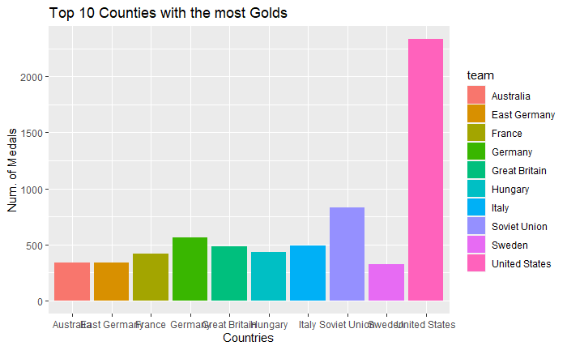

```r
ggplot(top_10) +
  geom_col(aes(x = team, y = count, fill = team)) +
  xlab("Countries") +
  ylab("Num. of Medals") +
  ggtitle("Top 10 Counties with the most Golds")
```

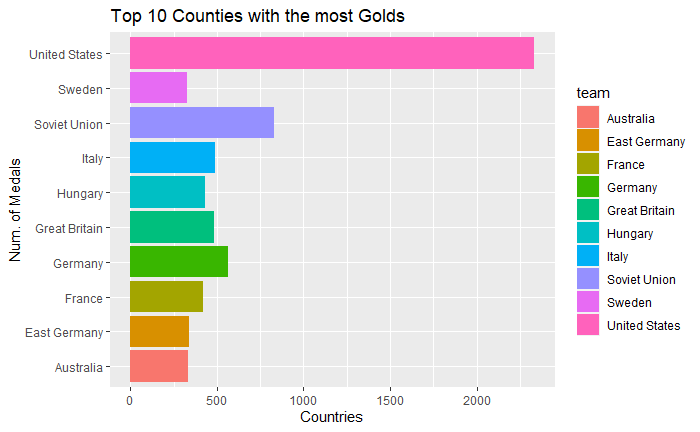

```r
ggplot(top_10) +
  geom_col(aes(x = count, y = team, fill = team)) +
  xlab("Countries") +
  ylab("Num. of Medals") +
  ggtitle("Top 10 Counties with the most Golds")
```

[output not shown]

[output cut: 912 more lines]

```r
library(janitor)
```

```r
chick_weight <- clean_names(ChickWeight)

head(chick_weight)
```

|  | weight | time | chick | diet |
| --- | --- | --- | --- | --- |
| 1 | 42 | 0 | 1 | 1 |
| 2 | 51 | 2 | 1 | 1 |
| 3 | 59 | 4 | 1 | 1 |
| 4 | 64 | 6 | 1 | 1 |
| 5 | 76 | 8 | 1 | 1 |
| 6 | 93 | 10 | 1 | 1 |

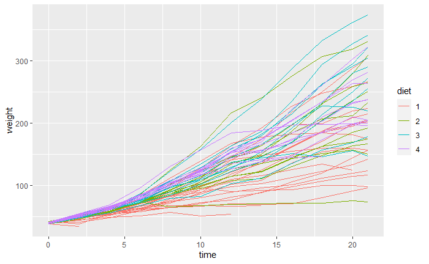

```r
ggplot(chick_weight) +
  geom_line(
    aes(x = time, y = weight, group = chick, colour = diet))
```

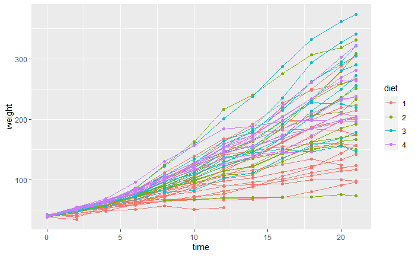

```r
ggplot(chick_weight) +
  geom_line(aes(x = time, y = weight, group = chick, colour = diet)) +
  geom_point(aes(x = time, y = weight, colour = diet))
```

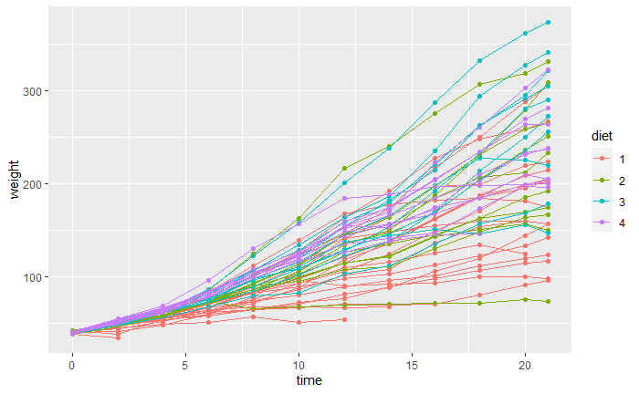

```r
ggplot(chick_weight) +
  geom_point(aes(x = time, y = weight, colour = diet)) +
  geom_line(aes(x = time, y = weight, group = chick, colour = diet))
```

```r
NA
NA
```

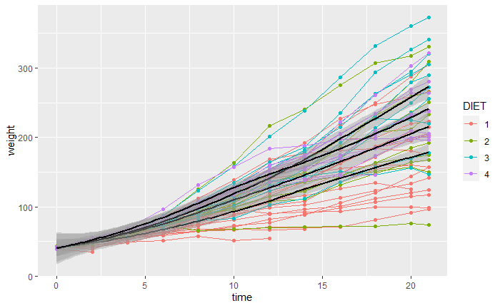

```r
ggplot(chick_weight,
       aes(x = time, y = weight,
           group = chick, colour = diet)) +
  geom_line() +
  geom_point() +
  geom_smooth(aes(group = diet), colour = "black") +
  labs(colour = "DIET")
```

can write it as below if only using the global data, makes it netter

```r
ggplot(chick_weight,
       aes(x = time, y = weight,
           group = chick, colour = diet)) +
  geom_line() +
  geom_point() +
  geom_smooth(aes(group = diet), colour = "black") +
  labs(colour = "DIET")
```

[output not shown]

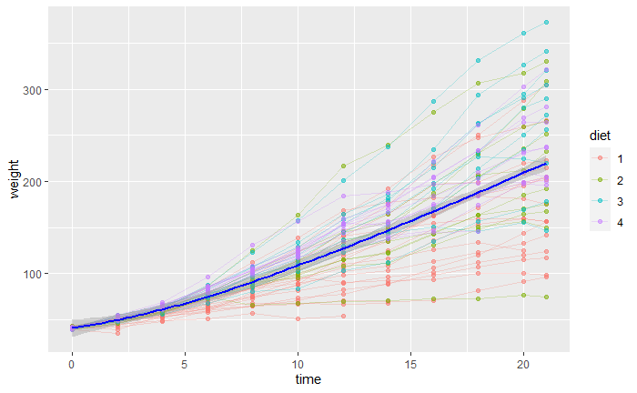

```r
ggplot(chick_weight) +
  geom_line(
    aes(x = time, y = weight, group = chick, colour = diet),
    alpha = 0.25
  ) +
  geom_point(
    aes(x = time, y = weight, colour = diet),
    alpha = 0.5
  ) +
  geom_smooth(
    aes(x = time, y = weight), colour = "blue")
```

```r
NA
```

```r
students <-  read_csv("clean_data/students.csv")
```

```
* `` -> ...1
```

### Use geom_point to make a scatter graph, with the height of students on the x-axis and their reaction time of the y axis.

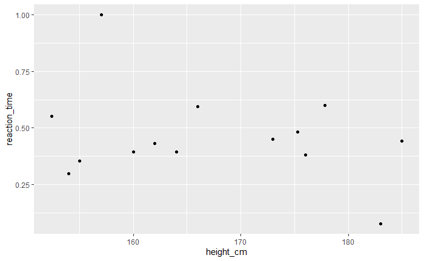

```r
ggplot(students) +
  geom_point(
    aes(x = height_cm, y = reaction_time)
  )
```

### Make all the points blue. For geom_bar, the colour of the bar is controlled by fill, but for geom_point the colour of the points are controlled by colour.

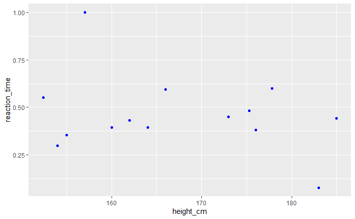

```r
ggplot(students) +
  geom_point(
    aes(x = height_cm, y = reaction_time), colour = "blue")
```

```r
NA
```

### Make the colour of the points depend on the superpower the student wishes they had.

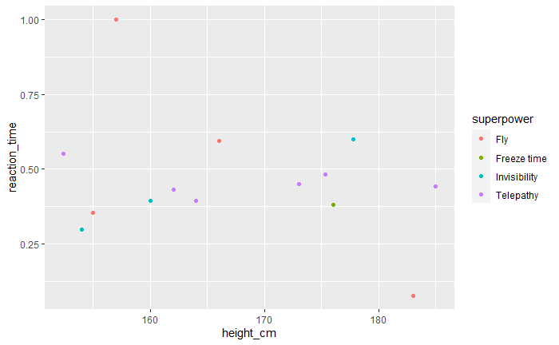

```r
ggplot(students) +
  geom_point(aes(x = height_cm, y = reaction_time, colour = superpower))
```

### Write down what the graph tells you overall.

There doesn’t seem to be much of a relationship between height and reaction type.

```r
pets <- read_csv("clean_data/pets.csv")
```

### We want age of the x-axis and weight on the y axis

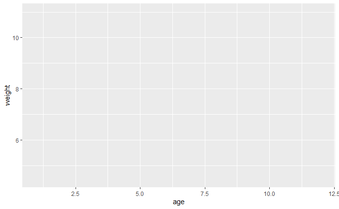

```r
ggplot(pets) +
  aes(x = age, y = weight)
```

### We want the points the be different colours depending on the gender of the pet

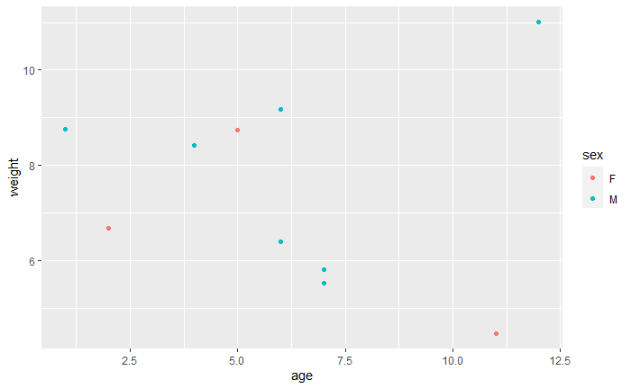

```r
ggplot(pets) +
  aes(x = age, y = weight) +
  geom_point(aes(colour = sex))
```

### We want different shapes depending on the type of animal

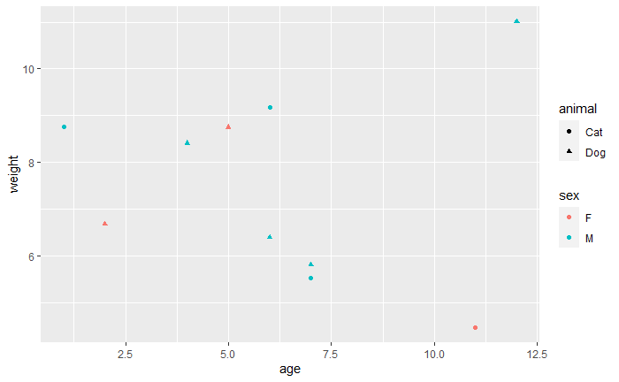

```r
ggplot(pets) +
  aes(x = age, y = weight) +
  geom_point(aes(colour = sex, shape = animal))
```

### We want all the points to be bigger than normal (size 4).

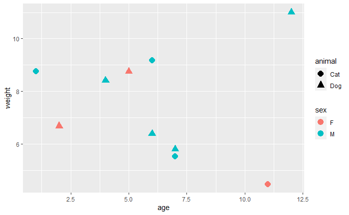

```r
ggplot(pets) +
  aes(x = age, y = weight) +
  geom_point(aes(colour = sex, shape = animal), size = 4)
```

### We also want labels with the pets names next to every point.

```r
ggplot(pets) +
  aes(x = age, y = weight) +
  geom_point(aes(colour = sex, shape = animal), size = 4) +
  geom_text(
    aes(label = name),
    nudge_x = 0.5,
    nudge_y = 0.1,
  )
```

[output not shown]

can use `hjust` to have the names move in towards the middle

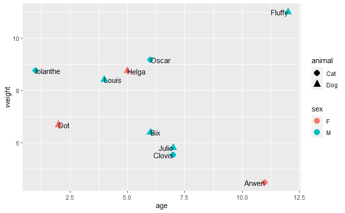

```r
ggplot(pets) +
  aes(x = age, y = weight) +
  geom_point(aes(colour = sex, shape = animal), size = 4) +
  geom_text(
    aes(label = name),
    hjust ="inward"
  )
```